# Ensemble Technique: Bagging and Boosting Project 4 - Travel Package Purhase

#### Insights - Duration of Pitch

- Outliers detected. This will be addressed in feature engineering section
- Data is skewed right
- Where Duration of Pitch is Null, Monthly Income might be null
- ProductPitched: Median Duration of Pitch: Basic:13, Deluxe:14, King: 11; Standard: 14; Super Deluxe: 13

#### Correlation Analysis

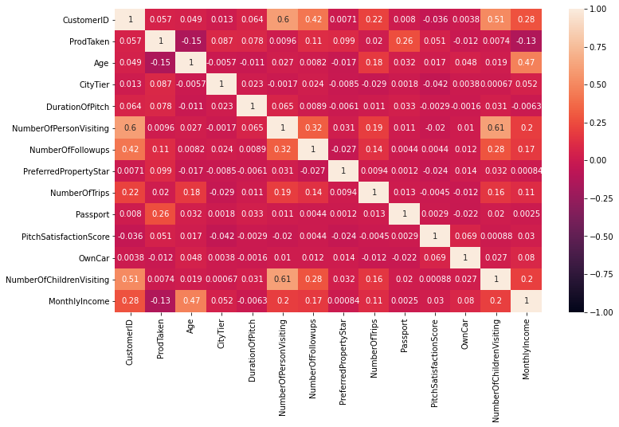

```python
plt.figure(figsize=(12,7))
sns.heatmap(data.corr(),annot=True,vmin=-1,vmax=1)
plt.show()
```

## Customer Profile: Assumption: Product pitched is the appropriate product for customer

- Basic
  - Product Pitched and ProdTaken Median Age: 30
  - Pitched primarily to City Tier 1 and City Tier 2 customers
  - Males were pitched Basic more than any other product type
  - Median income: 20582
  - Median Duration of Pitch:13
- Deluxe
  - Product Pitched and ProdTaken Median Age: 36
  - Customers in City Tier 3 were pitched this products most often
  - Females were pitched Deluxe more often that any other product type however, females do not appear to purchase the deluxe product at a higher rate than males
  - Married customers are mmore likley than no married couples to purchse Deluxe
  - Median Income: 23186
  - Median Duration of Pitch: 14
- King
  - Product Pitched and ProdTaken Median Age: 52
  - Married couples are more liley to purchase King Product that unmarried
  - Owning a car appears to influence the purchase of the King Product; Of those customers who were pitched a King product, 72% owned a car; Customers who buy the King Products have a higher rate of car ownership (90%) than those who take the other products (however these groups have a small number of customer each so consider size in evaluation)
  - Median Income: 34859
  - Median Duration of Pitch:11
- Standard
  - Product Pitched and ProdTaken Median Age: 38
  - Median number of trips is slightly lower for customers who purchse Standard
  - Product is pitched to all occupation groups
  - Median Income: 25711
  - Median Duration of Pitch: 14
- Super Deluxe
  - Product Pitched and ProdTaken Median Age: 42
  - Out of those who take the Super Deluxe product, 80% are company invited and 20% are self-enquiry
  - Purchase of product is influneced by a Preferredproperty star of 3 or greater
  - Number of Trips is slightly lower for those customers who purchase Super Deluxe
  - Median Income: 29802
  - Median Duration of Pitch: 13

## Section 2: EDA Insights

### Customer interaction data:

- PitchSatisfactionScore: Sales pitch satisfaction score
  - Pitch Satsifaction score percentages: 1:19%, 2:12%; 3:30%; 4:19%, 5:20%
  - The higher the Pitch Satsifactions score, the more likley the customer was to purchase the product
  - The pitch satisfaction score may not be influential for a model as the pitch score likely does nto occir before the customer chooses to take or not take the product.
  - Consider removing this variable from the model to avoid overfitting
- ProductPitched: Product pitched by the salesperson
  - Products pitched by percentage: Basic: 38%, Deluxe:35%, Standard: 15%, Super Deluxe: 7%, King: 5%
  - When ProductPitch:ProdTaken ratio - Basic:30%; Deluxe:12%; King:9%; Standard:17%; Super Deluxe: 6%
- NumberOfFollowups: Total number of follow-ups has been done by the salesperson after the sales pitch
  - Before Null replacement: Number of followups: Rate - 4.0:43%; 3.0:30%; 5.0:15%; 2.0:5%; 1.0:4%; 6.0: 3%
  - Follow-up rate does not change significantly when disaggregated by ProductPitched
  - Percent ProdTaken increase as number of Followups increases and Number of followups >=2
  - 46 Null values replaced with median(4)
- DurationOfPitch: Duration of the pitch by a salesperson to the customer
  - Outliers detected. This will be addressed in feature engineering section
  - Data is skewed right
  - Where Duration of Pitch is Null, Monthly Income might be null
  - ProductPitched: Median Duration of Pitch: Basic:13, Deluxe:14, King: 11; Standard: 14; Super Deluxe: 13

Possible Multi- colinearity Issues

- MOnthly Income and Age (0.47)
- Number of Person Visiting and Number of Children Visiting (0.61)

## Section 3: Data Pre-processing

- Missing Value treatment
- Outlier detection, if needed
- Feature Engineering
- Data Preparation

```python
#Determine which still have null values (after null value replacement that occurred during EDA)
data.info()
```

```
<class 'pandas.core.frame.DataFrame'>
RangeIndex: 4888 entries, 0 to 4887
Data columns (total 20 columns):
 #   Column                    Non-Null Count  Dtype
---  ------                    --------------  -----
 0   CustomerID                4888 non-null   int64
 1   ProdTaken                 4888 non-null   int64
 2   Age                       4888 non-null   float64
 3   TypeofContact             4888 non-null   object
 4   CityTier                  4888 non-null   int64
 5   DurationOfPitch           4637 non-null   float64
 6   Occupation                4888 non-null   object
 7   Gender                    4888 non-null   object
 8   NumberOfPersonVisiting    4888 non-null   int64
 9   NumberOfFollowups         4888 non-null   float64
 10  ProductPitched            4888 non-null   object
 11  PreferredPropertyStar     4888 non-null   float64
 12  MaritalStatus             4888 non-null   object
 13  NumberOfTrips             4888 non-null   float64
 14  Passport                  4888 non-null   int64
 15  PitchSatisfactionScore    4888 non-null   int64
 16  OwnCar                    4888 non-null   int64
 17  NumberOfChildrenVisiting  4822 non-null   float64
 18  Designation               4888 non-null   object
 19  MonthlyIncome             4655 non-null   float64
dtypes: float64(7), int64(7), object(6)
memory usage: 763.9+ KB
```

##### Missing values

- Duration of Pitch
- Number of children visiting
- Monthly Income

##### Outliers detected during EDA

- Number of Person visiting
- Number of Trips
- Monthly Income

Note: Treat Outliers prior to imputation for Monthly Income variable

##### Suspect Variables

- CustomerID: this is a seriel value and adds not information
- Designation: variable from the model for not apprpriate to contextit does not have designations hierarchically lower than manager, and products pitched to Managers were exclusively Deluxe and to Senior Managers exclusively Standard
- Pitch Satisfaction: The pitch satisfaction score may not be influential for a model as the pitch score likely does nto occir before the customer chooses to take or not take the product.
- Monthly Income and Age should be explored further for multicollinearity
- Number of Person visiting and Number of children visiting should be explored for multicollinearity

##### Explore Skewness and transformation

- Monthly Income
- Duration of Pitch
- Age

##### Object variables (review and understand); Use Dummy variable and/or replace structure to convert to ordinal type

- Type of contact
- Occupation
- Gender
- Product Pitched
- Marital Status
- Designation

#### Monthly Income Outlier Treatment and Replace Null values

```python
#Vire Monthly Income Null columns
MI_Null
```

|  | CustomerID | ProdTaken | Age | TypeofContact | CityTier | DurationOfPitch | Occupation | Gender | NumberOfPersonVisiting | NumberOfFollowups | ProductPitched | PreferredPropertyStar | MaritalStatus | NumberOfTrips | Passport | PitchSatisfactionScore | OwnCar | NumberOfChildrenVisiting | Designation | MonthlyIncome |
| --- | --- | --- | --- | --- | --- | --- | --- | --- | --- | --- | --- | --- | --- | --- | --- | --- | --- | --- | --- | --- |
| 11 | 200011 | 0 | 36.0 | Self Enquiry | 1 | 21.0 | Salaried | Female | 2 | 4.0 | Deluxe | 3.0 | Unmarried | 1.0 | 1 | 3 | 0 | 0.0 | Manager | NaN |
| 19 | 200019 | 0 | 32.0 | Self Enquiry | 1 | 8.0 | Salaried | Male | 2 | 3.0 | Basic | 3.0 | Unmarried | 6.0 | 1 | 4 | 0 | 1.0 | Executive | NaN |
| 20 | 200020 | 0 | 36.0 | Company Invited | 1 | 17.0 | Salaried | Female | 3 | 2.0 | Deluxe | 3.0 | Married | 1.0 | 0 | 3 | 1 | 2.0 | Manager | NaN |
| 26 | 200026 | 1 | 32.0 | Company Invited | 1 | 22.0 | Salaried | Female | 3 | 5.0 | Basic | 5.0 | Unmarried | 2.0 | 1 | 4 | 1 | 2.0 | Executive | NaN |
| 44 | 200044 | 0 | 36.0 | Company Invited | 1 | 6.0 | Small Business | Female | 2 | 3.0 | Deluxe | 3.0 | Unmarried | 2.0 | 0 | 3 | 1 | 0.0 | Manager | NaN |
| ... | ... | ... | ... | ... | ... | ... | ... | ... | ... | ... | ... | ... | ... | ... | ... | ... | ... | ... | ... | ... |
| 2390 | 202390 | 1 | 34.0 | Company Invited | 3 | NaN | Salaried | Female | 2 | 5.0 | Basic | 3.0 | Unmarried | 2.0 | 0 | 3 | 0 | 1.0 | Executive | NaN |
| 2399 | 202399 | 1 | 36.0 | Company Invited | 3 | 19.0 | Large Business | Female | 2 | 3.0 | Deluxe | 4.0 | Unmarried | 6.0 | 0 | 3 | 1 | 0.0 | Manager | NaN |
| 2410 | 202410 | 1 | 32.0 | Self Enquiry | 1 | 30.0 | Small Business | Male | 2 | 3.0 | Basic | 4.0 | Married | 2.0 | 1 | 1 | 0 | 0.0 | Executive | NaN |
| 2430 | 202430 | 1 | 32.0 | Self Enquiry | 1 | 14.0 | Small Business | Female | 3 | 3.0 | Basic | 5.0 | Married | 2.0 | 1 | 3 | 0 | 2.0 | Executive | NaN |
| 2431 | 202431 | 1 | 35.0 | Company Invited | 1 | NaN | Small Business | Male | 3 | 3.0 | Basic | 4.0 | Married | 2.0 | 1 | 3 | 1 | 0.0 | Executive | NaN |

233 rows × 20 columns

```python
# FMonthly Income Outlier detections (code from Intro to Supervised Learning - Data Preprocessing)
#Using the mean to detect outliers
def z_transform(x):
    return (x - np.mean(x)) / np.std(x)
```

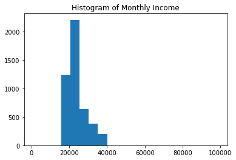

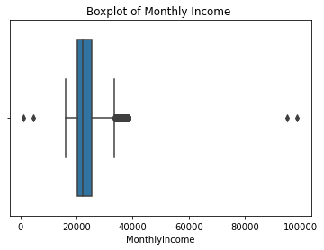

```python
plt.hist(data['MonthlyIncome'], 20)
plt.title('Histogram of Monthly Income')
plt.show()

sns.boxplot(data['MonthlyIncome'])
plt.title('Boxplot of Monthly Income ')
plt.show()
```

```python
##### Data is skewed so I will use the median to detect outliers
```

```python
# Locate points that are outside of 4 times the IQR
quartiles = np.quantile(data['MonthlyIncome'][data['MonthlyIncome'].notnull()], [.25, .75])
power_4iqr = 4 * (quartiles[1] - quartiles[0])
print(f'Q1 = {quartiles[0]}, Q3 = {quartiles[1]}, 4*IQR = {power_4iqr}')
outlier_powers = data.loc[np.abs(data['MonthlyIncome'] - data['MonthlyIncome'].median()) > power_4iqr, 'MonthlyIncome']
outlier_powers
```

```
Q1 = 20346.0, Q3 = 25571.0, 4*IQR = 20900.0
```

```
38      95000.0
142      1000.0
2482    98678.0
Name: MonthlyIncome, dtype: float64
```

```python
# Replace the outliers with Q1 for outliers below than the median and Q3 for outliers above the median
data['MonthlyIncome'].mask(data['MonthlyIncome'] > 90000,data['MonthlyIncome'].quantile(.75), inplace=True)
data['MonthlyIncome'].mask(data['MonthlyIncome'] < 1001,data['MonthlyIncome'].quantile(.25), inplace=True)
```

```python
print(data.loc[38]['MonthlyIncome'])
```

```
25571.0
```

```python
print(data.loc[142]['MonthlyIncome'])
```

```
20346.0
```

```python
print(data.loc[2482]['MonthlyIncome'])
```

```
25571.0
```

```python
data['MonthlyIncome'].describe().T
```

```
count     4655.000000
mean     23593.389474
std       5151.690725
min       4678.000000
25%      20346.000000
50%      22347.000000
75%      25571.000000
max      38677.000000
Name: MonthlyIncome, dtype: float64
```

```python
data['MonthlyIncome'].fillna(data['MonthlyIncome'].median(), inplace = True)
```

```python
data['MonthlyIncome'].isnull().sum()
```

```
0
```

##### Number of Person Visiting - Outlier Detection

```python
data.loc[(data['NumberOfTrips']>15)]
```

|  | CustomerID | ProdTaken | Age | TypeofContact | CityTier | DurationOfPitch | Occupation | Gender | NumberOfPersonVisiting | NumberOfFollowups | ProductPitched | PreferredPropertyStar | MaritalStatus | NumberOfTrips | Passport | PitchSatisfactionScore | OwnCar | NumberOfChildrenVisiting | Designation | MonthlyIncome |
| --- | --- | --- | --- | --- | --- | --- | --- | --- | --- | --- | --- | --- | --- | --- | --- | --- | --- | --- | --- | --- |
| 385 | 200385 | 1 | 30.0 | Company Invited | 1 | 10.0 | Large Business | Male | 2 | 3.0 | Basic | 3.0 | Unmarried | 19.0 | 1 | 4 | 1 | 1.0 | Executive | 17285.0 |
| 816 | 200816 | 0 | 39.0 | Company Invited | 1 | 15.0 | Salaried | Male | 3 | 3.0 | Deluxe | 4.0 | Unmarried | 21.0 | 0 | 2 | 1 | 0.0 | Manager | 21782.0 |
| 2829 | 202829 | 1 | 31.0 | Company Invited | 1 | 11.0 | Large Business | Male | 3 | 4.0 | Basic | 3.0 | Unmarried | 20.0 | 1 | 4 | 1 | 2.0 | Executive | 20963.0 |
| 3260 | 203260 | 0 | 40.0 | Company Invited | 1 | 16.0 | Salaried | Male | 4 | 4.0 | Deluxe | 4.0 | Unmarried | 22.0 | 0 | 2 | 1 | 1.0 | Manager | 25460.0 |

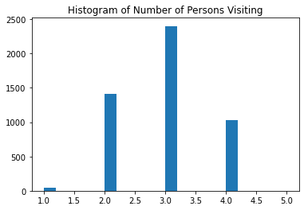

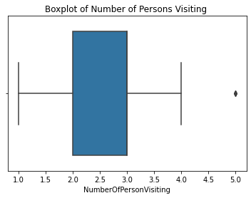

```python
plt.hist(data['NumberOfPersonVisiting'], 20)
plt.title('Histogram of Number of Persons Visiting')
plt.show()

sns.boxplot(data['NumberOfPersonVisiting'])
plt.title('Boxplot of Number of Persons Visiting ')
plt.show()
```

```python
data['NumberOfPersonVisiting'].value_counts()
```

```
3    2402
2    1418
4    1026
1      39
5       3
Name: NumberOfPersonVisiting, dtype: int64
```

###### Number of Persons visiting equals 5 occurs 3 times in the dataset; this is deemed acceptable for the problem statement and therefore these values will not be treated as outliers

##### Number of Trips Outlier detection

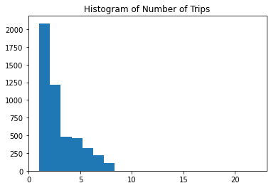

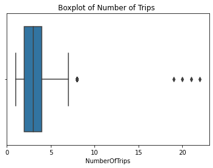

```python
plt.hist(data['NumberOfTrips'], 20)
plt.title('Histogram of Number of Trips')
plt.show()

sns.boxplot(data['NumberOfTrips'])
plt.title('Boxplot of Number of Trips ')
plt.show()
```

```python
data['NumberOfTrips'].value_counts()
```

```
2.0     1464
3.0     1219
1.0      620
4.0      478
5.0      458
6.0      322
7.0      218
8.0      105
21.0       1
19.0       1
22.0       1
20.0       1
Name: NumberOfTrips, dtype: int64
```

```python
data['NumberOfTrips'].describe().T
```

```
count    4888.000000
mean        3.229746
std         1.822769
min         1.000000
25%         2.000000
50%         3.000000
75%         4.000000
max        22.000000
Name: NumberOfTrips, dtype: float64
```

```python
# Locate points that are outside of 4 times the IQR
quartiles = np.quantile(data['NumberOfTrips'][data['NumberOfTrips'].notnull()], [.25, .75])
power_4iqr = 4 * (quartiles[1] - quartiles[0])
print(f'Q1 = {quartiles[0]}, Q3 = {quartiles[1]}, 4*IQR = {power_4iqr}')
outlier_powers = data.loc[np.abs(data['NumberOfTrips'] - data['NumberOfTrips'].median()) > power_4iqr, 'NumberOfTrips']
outlier_powers
```

```
Q1 = 2.0, Q3 = 4.0, 4*IQR = 8.0
```

```
385     19.0
816     21.0
2829    20.0
3260    22.0
Name: NumberOfTrips, dtype: float64
```

```python
data['NumberOfTrips'].mask(data['NumberOfTrips'] > 8,data['NumberOfTrips'].quantile(.75), inplace=True)
```

```python
# Recheck presence of Outliers
quartiles = np.quantile(data['NumberOfTrips'][data['NumberOfTrips'].notnull()], [.25, .75])
power_4iqr = 4 * (quartiles[1] - quartiles[0])
print(f'Q1 = {quartiles[0]}, Q3 = {quartiles[1]}, 4*IQR = {power_4iqr}')
outlier_powers = data.loc[np.abs(data['NumberOfTrips'] - data['NumberOfTrips'].median()) > power_4iqr, 'NumberOfTrips']
outlier_powers
```

```
Q1 = 2.0, Q3 = 4.0, 4*IQR = 8.0
```

```
Series([], Name: NumberOfTrips, dtype: float64)
```

#### Explore Multicollinearity of Variables 'Number of Persons visiting' and 'Number of Children'

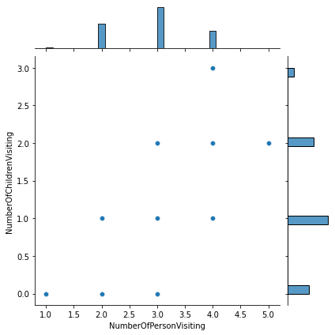

```python
sns.jointplot(data=data, x='NumberOfPersonVisiting', y='NumberOfChildrenVisiting')
```

```python
# 'NumberOfPersonVisitting' is the total number of persons visiting implying that this value includes the "NumberOfChildrenVisiting"
# The variable 'NumberOfChildrenVisiting' will be removed from the dataset
data.drop('NumberOfChildrenVisiting', axis=1, inplace=True)
data.info()
```

```
<class 'pandas.core.frame.DataFrame'>
RangeIndex: 4888 entries, 0 to 4887
Data columns (total 19 columns):
 #   Column                  Non-Null Count  Dtype
---  ------                  --------------  -----
 0   CustomerID              4888 non-null   int64
 1   ProdTaken               4888 non-null   int64
 2   Age                     4888 non-null   float64
 3   TypeofContact           4888 non-null   object
 4   CityTier                4888 non-null   int64
 5   DurationOfPitch         4637 non-null   float64
 6   Occupation              4888 non-null   object
 7   Gender                  4888 non-null   object
 8   NumberOfPersonVisiting  4888 non-null   int64
 9   NumberOfFollowups       4888 non-null   float64
 10  ProductPitched          4888 non-null   object
 11  PreferredPropertyStar   4888 non-null   float64
 12  MaritalStatus           4888 non-null   object
 13  NumberOfTrips           4888 non-null   float64
 14  Passport                4888 non-null   int64
 15  PitchSatisfactionScore  4888 non-null   int64
 16  OwnCar                  4888 non-null   int64
 17  Designation             4888 non-null   object
 18  MonthlyIncome           4888 non-null   float64
dtypes: float64(6), int64(7), object(6)
memory usage: 725.7+ KB
```

#### 'Duration of Pitch': Missing Values

```python
data['DurationOfPitch'].isnull().sum()
```

```
251
```

```python
data['DurationOfPitch'].describe().T
```

```
count    4637.000000
mean       15.490835
std         8.519643
min         5.000000
25%         9.000000
50%        13.000000
75%        20.000000
max       127.000000
Name: DurationOfPitch, dtype: float64
```

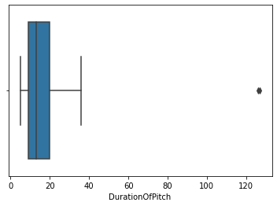

```python
sns.boxplot(data = data, x='DurationOfPitch')
```

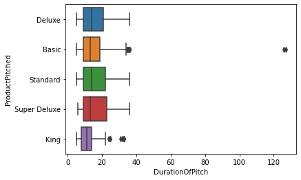

```python
sns.boxplot(data = data, x='DurationOfPitch', y='ProductPitched')
```

```python
data.groupby(['ProductPitched'])['DurationOfPitch'].median()
```

```
ProductPitched
Basic           13.0
Deluxe          14.0
King            11.0
Standard        14.0
Super Deluxe    13.0
Name: DurationOfPitch, dtype: float64
```

```python
# Impute null values with Product pitched group median
data['DurationOfPitch'] = data.groupby(['ProductPitched'], sort=False)['DurationOfPitch'].apply(lambda x: x.fillna(x.median()))

data['DurationOfPitch'].isnull().sum()
```

```
0
```

#### Drop non - informative columns

- CustomerID: this is a seriel value and adds not information
- Designation: variable from the model for not apprpriate to contextit does not have designations hierarchically lower than manager, and products pitched to Managers were exclusively Deluxe and to Senior Managers exclusively Standard
- Pitch Satisfaction: The pitch satisfaction score may not be influential for a model as the pitch score likely does nto occir before the customer chooses to take or not take the product.

```python
data.drop(['CustomerID','Designation','PitchSatisfactionScore'], axis = 1, inplace =True)
```

```python
data.info()
```

```
<class 'pandas.core.frame.DataFrame'>
RangeIndex: 4888 entries, 0 to 4887
Data columns (total 16 columns):
 #   Column                  Non-Null Count  Dtype
---  ------                  --------------  -----
 0   ProdTaken               4888 non-null   int64
 1   Age                     4888 non-null   float64
 2   TypeofContact           4888 non-null   object
 3   CityTier                4888 non-null   int64
 4   DurationOfPitch         4888 non-null   float64
 5   Occupation              4888 non-null   object
 6   Gender                  4888 non-null   object
 7   NumberOfPersonVisiting  4888 non-null   int64
 8   NumberOfFollowups       4888 non-null   float64
 9   ProductPitched          4888 non-null   object
 10  PreferredPropertyStar   4888 non-null   float64
 11  MaritalStatus           4888 non-null   object
 12  NumberOfTrips           4888 non-null   float64
 13  Passport                4888 non-null   int64
 14  OwnCar                  4888 non-null   int64
 15  MonthlyIncome           4888 non-null   float64
dtypes: float64(6), int64(5), object(5)
memory usage: 611.1+ KB
```

##### Explore Skewness and transformation

- Monthly Income
- Duration of Pitch
- Age

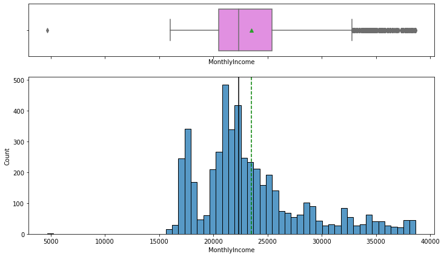

```python
#Monthly Inccome
# View Distribution of Numeric variable Monthly Income
histogram_boxplot(data, "MonthlyIncome")
```

##### Monthly Income is not skewed enough to warrant transformation before modeling

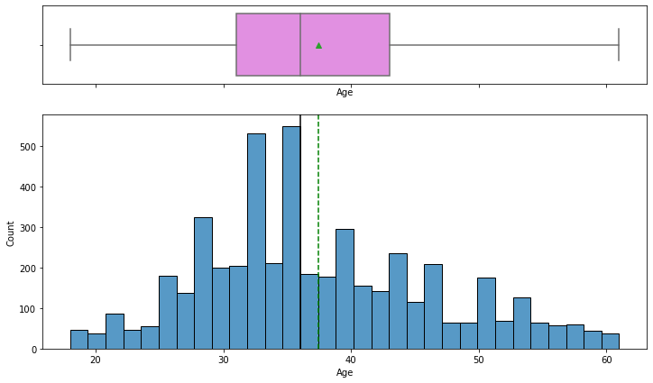

```python
#Age
# View Distribution of Numeric variable Monthly Income
histogram_boxplot(data, "Age")
```

##### Age is lightly skewed and does not warrant transformation before modeling

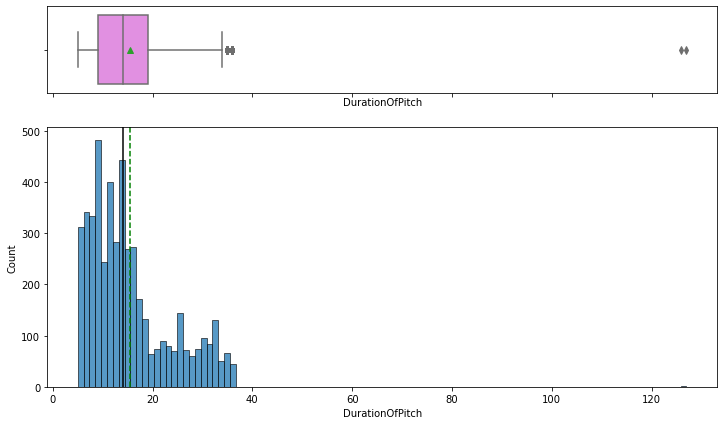

```python
##### Duration of Pitch
# View Distribution of Numeric variable Monthly Income
histogram_boxplot(data, "DurationOfPitch")
```

##### Duration of Pitch is not skewed enough to warrant transformation before modeling

#### Object data types: Explore and Convert to Ordinal types

```python
#Understand the number of each value for the following columns:
obj_cols = ['TypeofContact', 'Occupation','Gender','ProductPitched','MaritalStatus']
for col in obj_cols:
    print(data[col].value_counts())
    print("_________________________________")
```

```
Self Enquiry       3469
Company Invited    1419
Name: TypeofContact, dtype: int64
_________________________________
Salaried          2368
Small Business    2084
Large Business     434
Free Lancer          2
Name: Occupation, dtype: int64
_________________________________
Male      2916
Female    1972
Name: Gender, dtype: int64
_________________________________
Basic           1842
Deluxe          1732
Standard         742
Super Deluxe     342
King             230
Name: ProductPitched, dtype: int64
_________________________________
Unmarried    2548
Married      2340
Name: MaritalStatus, dtype: int64
_________________________________
```

```python
#Change object column dtypes to category dtype (Code from Hands on Bagging and Random Forest)

for feature in data.columns: # Loop through all columns in the dataframe
    if data[feature].dtype == 'object': # Only apply for columns with categorical strings
        data[feature] = pd.Categorical(data[feature])# Replace strings with an integer
data.head(10)
```

|  | ProdTaken | Age | TypeofContact | CityTier | DurationOfPitch | Occupation | Gender | NumberOfPersonVisiting | NumberOfFollowups | ProductPitched | PreferredPropertyStar | MaritalStatus | NumberOfTrips | Passport | OwnCar | MonthlyIncome |
| --- | --- | --- | --- | --- | --- | --- | --- | --- | --- | --- | --- | --- | --- | --- | --- | --- |
| 0 | 1 | 41.0 | Self Enquiry | 3 | 6.0 | Salaried | Female | 3 | 3.0 | Deluxe | 3.0 | Unmarried | 1.0 | 1 | 1 | 20993.0 |
| 1 | 0 | 49.0 | Company Invited | 1 | 14.0 | Salaried | Male | 3 | 4.0 | Deluxe | 4.0 | Unmarried | 2.0 | 0 | 1 | 20130.0 |
| 2 | 1 | 37.0 | Self Enquiry | 1 | 8.0 | Free Lancer | Male | 3 | 4.0 | Basic | 3.0 | Unmarried | 7.0 | 1 | 0 | 17090.0 |
| 3 | 0 | 33.0 | Company Invited | 1 | 9.0 | Salaried | Female | 2 | 3.0 | Basic | 3.0 | Unmarried | 2.0 | 1 | 1 | 17909.0 |
| 4 | 0 | 32.0 | Self Enquiry | 1 | 8.0 | Small Business | Male | 2 | 3.0 | Basic | 4.0 | Unmarried | 1.0 | 0 | 1 | 18468.0 |
| 5 | 0 | 32.0 | Company Invited | 1 | 8.0 | Salaried | Male | 3 | 3.0 | Basic | 3.0 | Unmarried | 1.0 | 0 | 1 | 18068.0 |
| 6 | 0 | 59.0 | Self Enquiry | 1 | 9.0 | Small Business | Female | 2 | 2.0 | Basic | 5.0 | Unmarried | 5.0 | 1 | 1 | 17670.0 |
| 7 | 0 | 30.0 | Self Enquiry | 1 | 30.0 | Salaried | Male | 3 | 3.0 | Basic | 3.0 | Married | 2.0 | 0 | 0 | 17693.0 |
| 8 | 0 | 38.0 | Company Invited | 1 | 29.0 | Salaried | Male | 2 | 4.0 | Standard | 3.0 | Unmarried | 1.0 | 0 | 0 | 24526.0 |
| 9 | 0 | 36.0 | Self Enquiry | 1 | 33.0 | Small Business | Male | 3 | 3.0 | Deluxe | 3.0 | Unmarried | 7.0 | 0 | 1 | 20237.0 |

```python
data.info()
```

```
<class 'pandas.core.frame.DataFrame'>
RangeIndex: 4888 entries, 0 to 4887
Data columns (total 16 columns):
 #   Column                  Non-Null Count  Dtype
---  ------                  --------------  -----
 0   ProdTaken               4888 non-null   int64
 1   Age                     4888 non-null   float64
 2   TypeofContact           4888 non-null   category
 3   CityTier                4888 non-null   int64
 4   DurationOfPitch         4888 non-null   float64
 5   Occupation              4888 non-null   category
 6   Gender                  4888 non-null   category
 7   NumberOfPersonVisiting  4888 non-null   int64
 8   NumberOfFollowups       4888 non-null   float64
 9   ProductPitched          4888 non-null   category
 10  PreferredPropertyStar   4888 non-null   float64
 11  MaritalStatus           4888 non-null   category
 12  NumberOfTrips           4888 non-null   float64
 13  Passport                4888 non-null   int64
 14  OwnCar                  4888 non-null   int64
 15  MonthlyIncome           4888 non-null   float64
dtypes: category(5), float64(6), int64(5)
memory usage: 444.7 KB
```

#### Convert Data types

- ONe hot encoding of categorical variables: Occupation, ProductPitched
- Convert to int64 via restructuring:
  - 'TypeofContact': Self Enguiry (0) and Company Invited (1)
  - 'Gender: Male (0) and Female (1)
  - 'Marital Status': Unmarried (0) and Married (1)

```python
replaceStruct = {
                "TypeofContact": {"Self Enquiry": 0, "Company Invited": 1},
                "Gender": {"Male": 0, "Female":1},
                 "MaritalStatus": {"Unmarried": 0, "Married":1 }
                    }
oneHotCols=['Occupation','ProductPitched']
```

```python
data=data.replace(replaceStruct)
data=pd.get_dummies(data, columns=oneHotCols)
data.head(10)
```

|  | ProdTaken | Age | TypeofContact | CityTier | DurationOfPitch | Gender | NumberOfPersonVisiting | NumberOfFollowups | PreferredPropertyStar | MaritalStatus | ... | MonthlyIncome | Occupation_Free Lancer | Occupation_Large Business | Occupation_Salaried | Occupation_Small Business | ProductPitched_Basic | ProductPitched_Deluxe | ProductPitched_King | ProductPitched_Standard | ProductPitched_Super Deluxe |
| --- | --- | --- | --- | --- | --- | --- | --- | --- | --- | --- | --- | --- | --- | --- | --- | --- | --- | --- | --- | --- | --- |
| 0 | 1 | 41.0 | 0 | 3 | 6.0 | 1 | 3 | 3.0 | 3.0 | 0 | ... | 20993.0 | 0 | 0 | 1 | 0 | 0 | 1 | 0 | 0 | 0 |
| 1 | 0 | 49.0 | 1 | 1 | 14.0 | 0 | 3 | 4.0 | 4.0 | 0 | ... | 20130.0 | 0 | 0 | 1 | 0 | 0 | 1 | 0 | 0 | 0 |
| 2 | 1 | 37.0 | 0 | 1 | 8.0 | 0 | 3 | 4.0 | 3.0 | 0 | ... | 17090.0 | 1 | 0 | 0 | 0 | 1 | 0 | 0 | 0 | 0 |
| 3 | 0 | 33.0 | 1 | 1 | 9.0 | 1 | 2 | 3.0 | 3.0 | 0 | ... | 17909.0 | 0 | 0 | 1 | 0 | 1 | 0 | 0 | 0 | 0 |
| 4 | 0 | 32.0 | 0 | 1 | 8.0 | 0 | 2 | 3.0 | 4.0 | 0 | ... | 18468.0 | 0 | 0 | 0 | 1 | 1 | 0 | 0 | 0 | 0 |
| 5 | 0 | 32.0 | 1 | 1 | 8.0 | 0 | 3 | 3.0 | 3.0 | 0 | ... | 18068.0 | 0 | 0 | 1 | 0 | 1 | 0 | 0 | 0 | 0 |
| 6 | 0 | 59.0 | 0 | 1 | 9.0 | 1 | 2 | 2.0 | 5.0 | 0 | ... | 17670.0 | 0 | 0 | 0 | 1 | 1 | 0 | 0 | 0 | 0 |
| 7 | 0 | 30.0 | 0 | 1 | 30.0 | 0 | 3 | 3.0 | 3.0 | 1 | ... | 17693.0 | 0 | 0 | 1 | 0 | 1 | 0 | 0 | 0 | 0 |
| 8 | 0 | 38.0 | 1 | 1 | 29.0 | 0 | 2 | 4.0 | 3.0 | 0 | ... | 24526.0 | 0 | 0 | 1 | 0 | 0 | 0 | 0 | 1 | 0 |
| 9 | 0 | 36.0 | 0 | 1 | 33.0 | 0 | 3 | 3.0 | 3.0 | 0 | ... | 20237.0 | 0 | 0 | 0 | 1 | 0 | 1 | 0 | 0 | 0 |

10 rows × 23 columns

```python
#Check dtypes for valriables and dummy variables
data.info()
```

```
<class 'pandas.core.frame.DataFrame'>
RangeIndex: 4888 entries, 0 to 4887
Data columns (total 23 columns):
 #   Column                       Non-Null Count  Dtype
---  ------                       --------------  -----
 0   ProdTaken                    4888 non-null   int64
 1   Age                          4888 non-null   float64
 2   TypeofContact                4888 non-null   int64
 3   CityTier                     4888 non-null   int64
 4   DurationOfPitch              4888 non-null   float64
 5   Gender                       4888 non-null   int64
 6   NumberOfPersonVisiting       4888 non-null   int64
 7   NumberOfFollowups            4888 non-null   float64
 8   PreferredPropertyStar        4888 non-null   float64
 9   MaritalStatus                4888 non-null   int64
 10  NumberOfTrips                4888 non-null   float64
 11  Passport                     4888 non-null   int64
 12  OwnCar                       4888 non-null   int64
 13  MonthlyIncome                4888 non-null   float64
 14  Occupation_Free Lancer       4888 non-null   uint8
 15  Occupation_Large Business    4888 non-null   uint8
 16  Occupation_Salaried          4888 non-null   uint8
 17  Occupation_Small Business    4888 non-null   uint8
 18  ProductPitched_Basic         4888 non-null   uint8
 19  ProductPitched_Deluxe        4888 non-null   uint8
 20  ProductPitched_King          4888 non-null   uint8
 21  ProductPitched_Standard      4888 non-null   uint8
 22  ProductPitched_Super Deluxe  4888 non-null   uint8
dtypes: float64(6), int64(8), uint8(9)
memory usage: 577.7 KB
```

## Section 4: Model Building - Bagging (using code from the MLS_HR Attrition examples in Great Learning course content)

- Build Bagging classifier
- Random Forest
- Decision Tree
- Model Performance

```python
#ProdTaken is the targe variable
X = data.drop("ProdTaken" , axis=1)
y = data.pop("ProdTaken")
```

```python
#  Test/Train Split
X_train, X_test, y_train, y_test = train_test_split(X, y, test_size=.30, random_state=1,stratify=y)
```

##### Functions to calulate Confusion Matrix, Accuracy, Recall and Precision and F1

```python
## Function to create confusion matrix
def confusion_matrix_sklearn(model, predictors, target):
    """
    To plot the confusion_matrix with percentages

    model: classifier
    predictors: independent variables
    target: dependent variable
    """
    y_pred = model.predict(predictors)
    cm = confusion_matrix(target, y_pred)
    labels = np.asarray(
        [
            ["{0:0.0f}".format(item) + "\n{0:.2%}".format(item / cm.flatten().sum())]
            for item in cm.flatten()
        ]
    ).reshape(2, 2)

    plt.figure(figsize=(6, 4))
    sns.heatmap(cm, annot=labels, fmt="")
    plt.ylabel("True label")
    plt.xlabel("Predicted label")
```

```python
##  Function to calculate different metric scores of the model - Accuracy, Recall and Precision
# defining a function to compute different metrics to check performance of a classification model built using sklearn
def model_performance_classification_sklearn(model, predictors, target):
    """
    Function to compute different metrics to check classification model performance

    model: classifier
    predictors: independent variables
    target: dependent variable
    """

    # predicting using the independent variables
    pred = model.predict(predictors)

    acc = accuracy_score(target, pred)  # to compute Accuracy
    recall = recall_score(target, pred)  # to compute Recall
    precision = precision_score(target, pred)  # to compute Precision
    f1 = f1_score(target, pred)  # to compute F1-score

    # creating a dataframe of metrics
    df_perf = pd.DataFrame(
        {
            "Accuracy": acc,
            "Recall": recall,
            "Precision": precision,
            "F1": f1,
        },
        index=[0],
    )

    return df_perf
```

#### Decision Tree Model

```python
#Determine class weights for Decision Tree
y.value_counts(normalize=True)
```

```
0    0.811784
1    0.188216
Name: ProdTaken, dtype: float64
```

##### Choose class_weights={0:0.19,1:0.81} because that is the original imbalance in our data.

```python
dtree = DecisionTreeClassifier(criterion='gini',class_weight={0:0.19,1:0.81},random_state=1)
```

```python
dtree.fit(X_train, y_train)
```

```
DecisionTreeClassifier(class_weight={0: 0.19, 1: 0.81}, random_state=1)
```

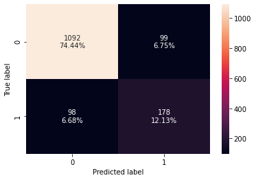

```python
confusion_matrix_sklearn(dtree, X_test, y_test)
```

```python
dtree_model_train_perf=model_performance_classification_sklearn(dtree, X_train, y_train)
print("Training performance \n",dtree_model_train_perf)
```

```
Training performance
    Accuracy  Recall  Precision   F1
0       1.0     1.0        1.0  1.0
```

```python
dtree_model_test_perf=model_performance_classification_sklearn(dtree, X_test, y_test)
print("Testing performance \n",dtree_model_test_perf)
```

```
Testing performance
    Accuracy    Recall  Precision        F1
0  0.865712  0.644928   0.642599  0.643761
```

##### Decision tree is working well on the training data but is not able to generalize well on the test data concerning the F1 score, which is the preferred metric for this Use Case

F1 score is the dedired metric:  
For this model, a false positive is identifying the purchase of a product when their was not purchse. A False negative is identifying no purchase when there was actuall a purchase. Neither False Positive nor false negatives have higher costs associated to them from a business standpoint. Since the mode is predicting the purchase of a product, recall is important but is not the only metric by which to measure model success.therefore Precision is also a desired metric (we need to know the cost of false negatives and false positives). Therefore, the primary measure of model success will be the F1 score (a function of both precision and recall)

#### Bagging Classifier

```python
bagging = BaggingClassifier(random_state=1)
bagging.fit(X_train,y_train)
```

```
BaggingClassifier(random_state=1)
```

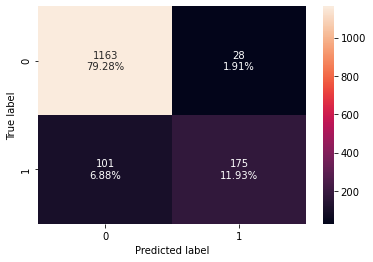

```python
confusion_matrix_sklearn(bagging, X_test, y_test)
```

```python
bagging_model_train_perf=model_performance_classification_sklearn(bagging, X_train, y_train)
print("Training performance \n",bagging_model_train_perf)
```

```
Training performance
    Accuracy    Recall  Precision        F1
0  0.995031  0.975155    0.99841  0.986646
```

```python
bagging_model_test_perf=model_performance_classification_sklearn(bagging, X_test, y_test)
print("Testing performance \n",bagging_model_test_perf)
```

```
Testing performance
    Accuracy    Recall  Precision        F1
0  0.912065  0.634058   0.862069  0.730689
```

##### Bagging classifier is overfitting on the training set and is performing poorly on the test set in terms of F1 score.

```python
# Apply class weights to Bagging
bagging_wt = BaggingClassifier(base_estimator=DecisionTreeClassifier(criterion='gini',class_weight={0:0.18,1:0.81},random_state=1),random_state=1)
bagging_wt.fit(X_train,y_train)
```

```
BaggingClassifier(base_estimator=DecisionTreeClassifier(class_weight={0: 0.18,
                                                                      1: 0.81},
                                                        random_state=1),
                  random_state=1)
```

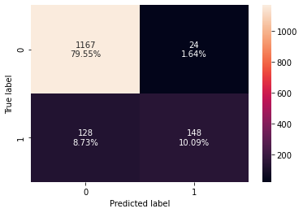

```python
confusion_matrix_sklearn(bagging_wt,X_test,y_test)
```

```python
bagging_wt_model_train_perf=model_performance_classification_sklearn(bagging_wt,X_train,y_train)
print("Training performance \n",bagging_wt_model_train_perf)
```

```
Training performance
    Accuracy    Recall  Precision        F1
0  0.992692  0.964286    0.99679  0.980268
```

```python
bagging_wt_model_test_perf=model_performance_classification_sklearn(bagging_wt, X_test, y_test)
print("Testing performance \n",bagging_wt_model_test_perf)
```

```
Testing performance
    Accuracy    Recall  Precision        F1
0  0.896387  0.536232   0.860465  0.660714
```

##### Applying class weights descreased F1 score performance. model is not generalizing well on test data.

#### Random Forest Model

```python
rf = RandomForestClassifier(random_state=1)
rf.fit(X_train,y_train)
```

```
RandomForestClassifier(random_state=1)
```

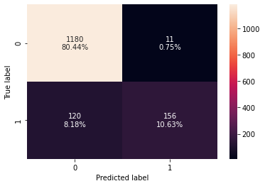

```python
confusion_matrix_sklearn(rf,X_test,y_test)
```

```python
rf_model_train_perf=model_performance_classification_sklearn(rf,X_train,y_train)
print("Training performance \n",rf_model_train_perf)
```

```
Training performance
    Accuracy  Recall  Precision   F1
0       1.0     1.0        1.0  1.0
```

```python
rf_model_test_perf=model_performance_classification_sklearn(rf,X_test,y_test)
print("Testing performance \n",rf_model_test_perf)
```

```
Testing performance
    Accuracy    Recall  Precision        F1
0  0.910702  0.565217   0.934132  0.704289
```

#### Random classifer with class weights

```python
rf_wt = RandomForestClassifier(class_weight={0:0.19,1:0.81}, random_state=1)
rf_wt.fit(X_train,y_train)
```

```
RandomForestClassifier(class_weight={0: 0.19, 1: 0.81}, random_state=1)
```

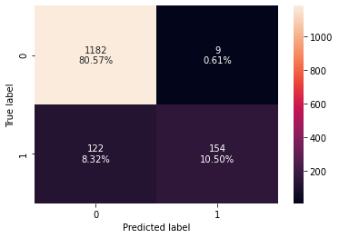

```python
confusion_matrix_sklearn(rf_wt, X_test,y_test)
```

```python
rf_wt_model_train_perf=model_performance_classification_sklearn(rf_wt, X_train,y_train)
print("Training performance \n",rf_wt_model_train_perf)
```

```
Training performance
    Accuracy  Recall  Precision   F1
0       1.0     1.0        1.0  1.0
```

```python
rf_wt_model_test_perf=model_performance_classification_sklearn(rf_wt, X_test,y_test)
print("Testing performance \n",rf_wt_model_test_perf)
```

```
Testing performance
    Accuracy    Recall  Precision        F1
0  0.910702  0.557971   0.944785  0.701595
```

## Section 5: Model Performance Improvement - Bagging

- Model performance metric
- Model performance after tuning the Decision Tree, Bagging and Randon Forest classifier

F1 score is the desired metric: For this model, a false positive is identifying the purchase of a product when their was not purchse. A False negative is identifying no purchase when there was actuall a purchase. Neither False Positive nor false negatives have higher costs associated to them from a business standpoint. Since the mode is predicting the purchase of a product, recall is important but is not the only metric by which to measure model success.therefore Precision is also a desired metric (we need to know the cost of false negatives and false positives). Therefore, the primary measure of model success will be the F1 score (a function of both precision and recall)

### Tuning the Decision Tree classifier

```python
# Choose the type of classifier.
dtree_estimator = DecisionTreeClassifier(random_state=1)

# Grid of parameters to choose from
parameters = {'max_depth': np.arange(2,30),
              'min_samples_leaf': [1, 2, 5, 7, 10],
              'max_leaf_nodes' : [2, 3, 5, 10,15, None],
              'min_impurity_decrease': [0.0001,0.001,0.01,0.1]
             }

# Type of scoring used to compare parameter combinations
scorer = metrics.make_scorer(metrics.recall_score)

# Run the grid search
grid_obj = GridSearchCV(dtree_estimator, parameters, scoring=scorer)
grid_obj = grid_obj.fit(X_train, y_train)

# Set the clf to the best combination of parameters
dtree_estimator = grid_obj.best_estimator_

# Fit the best algorithm to the data.
dtree_estimator.fit(X_train, y_train)
```

```
DecisionTreeClassifier(max_depth=24, min_impurity_decrease=0.0001,
                       random_state=1)
```

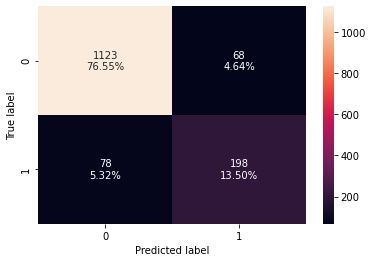

```python
confusion_matrix_sklearn(dtree_estimator, X_test,y_test)
```

```python
dtree_estimator_model_train_perf=model_performance_classification_sklearn(dtree_estimator, X_train,y_train)
print("Training performance \n",dtree_estimator_model_train_perf)
```

```
Training performance
    Accuracy    Recall  Precision        F1
0  0.991523  0.958075   0.996769  0.977039
```

```python
dtree_estimator_model_test_perf=model_performance_classification_sklearn(dtree_estimator, X_test, y_test)
print("Testing performance \n",dtree_estimator_model_test_perf)
```

```
Testing performance
    Accuracy    Recall  Precision        F1
0  0.900477  0.717391   0.744361  0.730627
```

##### Through Tuning the F1 score of the model was improved from .64 to .73 - an improvement but not the desire model score.

### Tuning the Bagging classifier

```python
# grid search for bagging classifier
cl1 = DecisionTreeClassifier(random_state=1)
param_grid = {'base_estimator':[cl1],
              'n_estimators':[5,7,15,51,101],
              'max_features': [0.7,0.8,0.9,1]
             }

grid = GridSearchCV(BaggingClassifier(random_state=1,bootstrap=True), param_grid=param_grid, scoring = 'recall', cv = 5)
grid.fit(X_train, y_train)
```

```
GridSearchCV(cv=5, estimator=BaggingClassifier(random_state=1),
             param_grid={'base_estimator': [DecisionTreeClassifier(random_state=1)],
                         'max_features': [0.7, 0.8, 0.9, 1],
                         'n_estimators': [5, 7, 15, 51, 101]},
             scoring='recall')
```

```python
## getting the best estimator
bagging_estimator  = grid.best_estimator_
bagging_estimator.fit(X_train,y_train)
```

```
BaggingClassifier(base_estimator=DecisionTreeClassifier(random_state=1),
                  max_features=0.9, n_estimators=15, random_state=1)
```

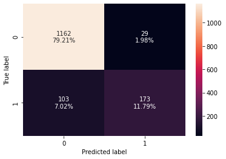

```python
confusion_matrix_sklearn(bagging_estimator, X_test,y_test)
```

```python
bagging_estimator_model_train_perf=model_performance_classification_sklearn(bagging_estimator, X_train,y_train)
print("Training performance \n",bagging_estimator_model_train_perf)
```

```
Training performance
    Accuracy   Recall  Precision       F1
0  0.997662  0.98913   0.998433  0.99376
```

```python
bagging_estimator_model_test_perf=model_performance_classification_sklearn(bagging_estimator, X_test, y_test)
print("Testing performance \n",bagging_estimator_model_test_perf)
```

```
Testing performance
    Accuracy    Recall  Precision        F1
0   0.91002  0.626812   0.856436  0.723849
```

### Tuning the Random Forest Classifier

```python
# Choose the type of classifier.
rf_estimator = RandomForestClassifier(random_state=1)

# Grid of parameters to choose from
parameters = {
        "n_estimators": [110,251,501],
        "min_samples_leaf": np.arange(1, 6,1),
        "max_features": [0.7,0.9,'log2','auto'],
        "max_samples": [0.7,0.9,None],
}

# Run the grid search
grid_obj = GridSearchCV(rf_estimator, parameters, scoring='recall',cv=5)
grid_obj = grid_obj.fit(X_train, y_train)

# Set the clf to the best combination of parameters
rf_estimator = grid_obj.best_estimator_

# Fit the best algorithm to the data.
rf_estimator.fit(X_train, y_train)
```

```
RandomForestClassifier(max_features=0.7, n_estimators=110, random_state=1)
```

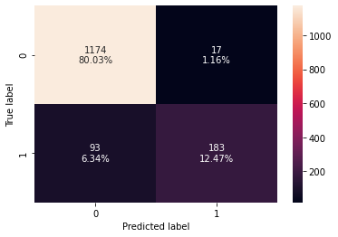

```python
confusion_matrix_sklearn(rf_estimator, X_test,y_test)
```

```python
rf_estimator_model_train_perf=model_performance_classification_sklearn(rf_estimator, X_train,y_train)
print("Training performance \n",rf_estimator_model_train_perf)
```

```
Training performance
    Accuracy  Recall  Precision   F1
0       1.0     1.0        1.0  1.0
```

```python
rf_estimator_model_test_perf=model_performance_classification_sklearn(rf_estimator, X_test, y_test)
print("Testing performance \n",rf_estimator_model_test_perf)
```

```
Testing performance
    Accuracy    Recall  Precision        F1
0  0.925017  0.663043      0.915  0.768908
```

##### Through Tuning the F1 score of the model was improved from .70 to .77 - the tuned Random Forest model is the best of the models so far (of Decision tree classifier, Bagging Classifier and Random classifier)

```python
# training performance comparison

models_train_comp_df = pd.concat(
    [dtree_model_train_perf.T,bagging_model_train_perf.T, bagging_wt_model_train_perf.T,rf_model_train_perf.T,
    rf_wt_model_train_perf.T,dtree_estimator_model_train_perf.T, bagging_estimator_model_train_perf.T,
     rf_estimator_model_train_perf.T],
    axis=1,
)
models_train_comp_df.columns = [
    "Decision Tree",
    "Bagging Classifier",
    "Weighted Bagging Classifier",
    "Random Forest Classifier",
    "Weighted Random Forest Classifier",
    "Decision Tree Estimator",
    "Bagging Estimator",
    "Random Forest Estimator"]
print("Training performance comparison:")
models_train_comp_df
```

```
Training performance comparison:
```

|  | Decision Tree | Bagging Classifier | Weighted Bagging Classifier | Random Forest Classifier | Weighted Random Forest Classifier | Decision Tree Estimator | Bagging Estimator | Random Forest Estimator |
| --- | --- | --- | --- | --- | --- | --- | --- | --- |
| Accuracy | 1.0 | 0.995031 | 0.992692 | 1.0 | 1.0 | 0.991523 | 0.997662 | 1.0 |
| Recall | 1.0 | 0.975155 | 0.964286 | 1.0 | 1.0 | 0.958075 | 0.989130 | 1.0 |
| Precision | 1.0 | 0.998410 | 0.996790 | 1.0 | 1.0 | 0.996769 | 0.998433 | 1.0 |
| F1 | 1.0 | 0.986646 | 0.980268 | 1.0 | 1.0 | 0.977039 | 0.993760 | 1.0 |

```python
# training performance comparison

models_test_comp_df = pd.concat(
    [dtree_model_test_perf.T,bagging_model_test_perf.T, bagging_wt_model_test_perf.T,rf_model_test_perf.T,
    rf_wt_model_test_perf.T,dtree_estimator_model_test_perf.T, bagging_estimator_model_test_perf.T,
     rf_estimator_model_test_perf.T],
    axis=1,
)
models_test_comp_df.columns = [
    "Decision Tree",
    "Bagging Classifier",
    "Weighted Bagging Classifier",
    "Random Forest Classifier",
    "Weighted Random Forest Classifier",
    "Decision Tree Estimator",
    "Bagging Estimator",
    "Random Forest Estimator"]
print("Testing performance comparison:")
models_test_comp_df
```

```
Testing performance comparison:
```

|  | Decision Tree | Bagging Classifier | Weighted Bagging Classifier | Random Forest Classifier | Weighted Random Forest Classifier | Decision Tree Estimator | Bagging Estimator | Random Forest Estimator |
| --- | --- | --- | --- | --- | --- | --- | --- | --- |
| Accuracy | 0.865712 | 0.912065 | 0.896387 | 0.910702 | 0.910702 | 0.900477 | 0.910020 | 0.925017 |
| Recall | 0.644928 | 0.634058 | 0.536232 | 0.565217 | 0.557971 | 0.717391 | 0.626812 | 0.663043 |
| Precision | 0.642599 | 0.862069 | 0.860465 | 0.934132 | 0.944785 | 0.744361 | 0.856436 | 0.915000 |
| F1 | 0.643761 | 0.730689 | 0.660714 | 0.704289 | 0.701595 | 0.730627 | 0.723849 | 0.768908 |

#### Random Forest Estimator model achieved best model performance as evaluated using the F1 score with a score of .77

```python
# importance of features in the tree building ( The importance of a feature is computed as the
#(normalized) total reduction of the criterion brought by that feature. It is also known as the Gini importance )

print (pd.DataFrame(rf.feature_importances_, columns = ["Imp"], index = X_train.columns).sort_values(by = 'Imp', ascending = False))
```

```
                                  Imp
MonthlyIncome                0.157471
Age                          0.141369
DurationOfPitch              0.122793
NumberOfTrips                0.078799
Passport                     0.073717
NumberOfFollowups            0.062679
PreferredPropertyStar        0.048958
CityTier                     0.041467
NumberOfPersonVisiting       0.036907
ProductPitched_Basic         0.032918
TypeofContact                0.030458
Gender                       0.030185
MaritalStatus                0.026594
OwnCar                       0.025068
Occupation_Small Business    0.020274
Occupation_Salaried          0.018709
Occupation_Large Business    0.016320
ProductPitched_Deluxe        0.015359
ProductPitched_Standard      0.011205
ProductPitched_Super Deluxe  0.005648
ProductPitched_King          0.002879
Occupation_Free Lancer       0.000220
```

```python
feature_names = X_train.columns
```

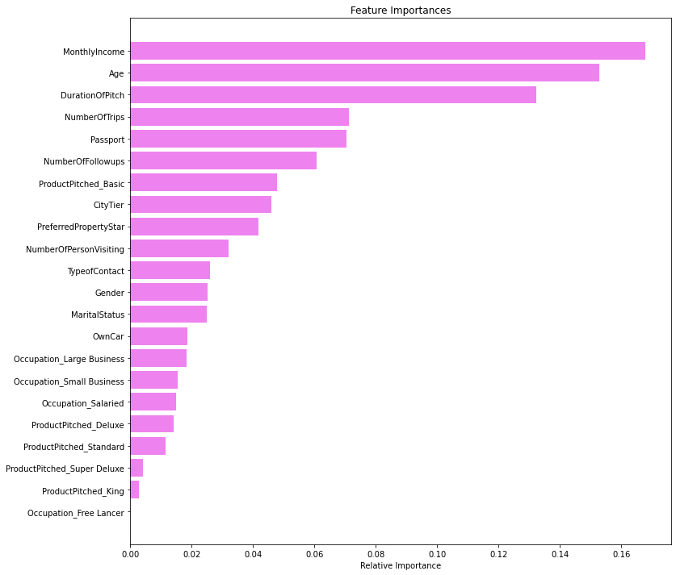

```python
importances = rf_estimator.feature_importances_
indices = np.argsort(importances)

plt.figure(figsize=(12,12))
plt.title('Feature Importances')
plt.barh(range(len(indices)), importances[indices], color='violet', align='center')
plt.yticks(range(len(indices)), [feature_names[i] for i in indices])
plt.xlabel('Relative Importance')
plt.show()
```

#### Most important features for informing the model are displayed above with the top 3: Monthly Income, Age and Duration of Pitch. This information will be combined with information from EDA to make business recommendations tot he client .

## Section 6: Model building - Boosting (Code from Ensemble Hands on Boosting from Great learning Course Content)

- Adaboost, GradientBoost, XGBoost and Stacking classifiers
- Model Performance

#### AdaBoost Classifier

```python
!pip install xgboost
```

```python
from sklearn.tree import DecisionTreeClassifier
from sklearn.ensemble import AdaBoostClassifier, GradientBoostingClassifier
from xgboost import XGBClassifier
```

```python
abc = AdaBoostClassifier(random_state=1)
abc.fit(X_train,y_train)
```

```
AdaBoostClassifier(random_state=1)
```

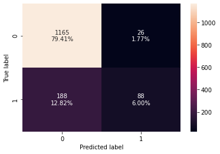

```python
confusion_matrix_sklearn(abc, X_test,y_test)
```

```python
abc_model_train_perf=model_performance_classification_sklearn(abc, X_train,y_train)
print("Training performance \n",abc_model_train_perf)
```

```
Training performance
    Accuracy    Recall  Precision        F1
0  0.849459  0.312112   0.736264  0.438386
```

```python
abc_model_test_perf=model_performance_classification_sklearn(abc, X_test, y_test)
print("Testing performance \n",abc_model_test_perf)
```

```
Testing performance
    Accuracy    Recall  Precision        F1
0  0.854124  0.318841    0.77193  0.451282
```

##### Adaboost model is not overfitting however the F1 score for test data is .45, well below the desired value for the metric used to evaluate all models.

#### Gradient Booster

```python
gbc = GradientBoostingClassifier(random_state=1)
gbc.fit(X_train,y_train)
```

```
GradientBoostingClassifier(random_state=1)
```

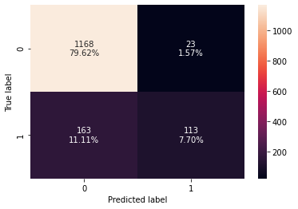

```python
confusion_matrix_sklearn(gbc, X_test,y_test)
```

```python
gbc_model_train_perf=model_performance_classification_sklearn(gbc, X_train,y_train)
print("Training performance \n",gbc_model_train_perf)
```

```
Training performance
    Accuracy    Recall  Precision        F1
0  0.883075  0.434783   0.886076  0.583333
```

```python
gbc_model_test_perf=model_performance_classification_sklearn(gbc, X_test, y_test)
print("Testing performance \n",gbc_model_test_perf)
```

```
Testing performance
    Accuracy   Recall  Precision        F1
0  0.873211  0.40942   0.830882  0.548544
```

##### Gradient Boost classifier model is not overfitting and is an improved model over the Adaboost with an F1 score of .55 on test data.

#### XG Boost

```python
xgb = XGBClassifier(random_state=1,eval_metric='logloss')
xgb.fit(X_train, y_train)
```

```
XGBClassifier(base_score=0.5, booster='gbtree', colsample_bylevel=1,
              colsample_bynode=1, colsample_bytree=1, eval_metric='logloss',
              gamma=0, gpu_id=-1, importance_type='gain',
              interaction_constraints='', learning_rate=0.300000012,
              max_delta_step=0, max_depth=6, min_child_weight=1, missing=nan,
              monotone_constraints='()', n_estimators=100, n_jobs=8,
              num_parallel_tree=1, random_state=1, reg_alpha=0, reg_lambda=1,
              scale_pos_weight=1, subsample=1, tree_method='exact',
              validate_parameters=1, verbosity=None)
```

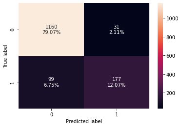

```python
confusion_matrix_sklearn(xgb, X_test,y_test)
```

```python
xgb_model_train_perf=model_performance_classification_sklearn(xgb, X_train,y_train)
print("Training performance \n",xgb_model_train_perf)
```

```
Training performance
    Accuracy    Recall  Precision        F1
0  0.998831  0.993789        1.0  0.996885
```

```python
xgb_model_test_perf=model_performance_classification_sklearn(xgb, X_test, y_test)
print("Testing performance \n",xgb_model_test_perf)
```

```
Testing performance
    Accuracy    Recall  Precision        F1
0  0.911384  0.641304   0.850962  0.731405
```

##### Model F1 score is significantly improved over previous boosting techniques with an F1 score of .73

With default Parameters, of the 3 Boosting techniques used, XGBoost has the best performance with an F1 score of .73

## Section 7: Model Performance Improvement - Boosting

- Model performance metric
- Model performance after tuning the AdaBoost and Gradient Boosting classifier

NOTE: XGBoost will increase runtime

F1 score is the desired metric: For this model, a false positive is identifying the purchase of a product when their was not purchse. A False negative is identifying no purchase when there was actuall a purchase. Neither False Positive nor false negatives have higher costs associated to them from a business standpoint. Since the mode is predicting the purchase of a product, recall is important but is not the only metric by which to measure model success.therefore Precision is also a desired metric (we need to know the cost of false negatives and false positives). Therefore, the primary measure of model success will be the F1 score (a function of both precision and recall)

```python
#### ADABoost model with Tuning
```

```python
# Choose the type of classifier.
abc_tuned = AdaBoostClassifier(random_state=1)

# Grid of parameters to choose from
## add from article
parameters = {
    #Let's try different max_depth for base_estimator
    "base_estimator":[DecisionTreeClassifier(max_depth=1, random_state=1),DecisionTreeClassifier(max_depth=2, random_state=1),DecisionTreeClassifier(max_depth=3, random_state=1)],
    "n_estimators": np.arange(10,110,10),
    "learning_rate":np.arange(0.1,2,0.1)
}



# Run the grid search
grid_obj = GridSearchCV(abc_tuned, parameters, scoring=acc_scorer,cv=5)
grid_obj = grid_obj.fit(X_train, y_train)

# Set the clf to the best combination of parameters
abc_tuned = grid_obj.best_estimator_

# Fit the best algorithm to the data.
abc_tuned.fit(X_train, y_train)
```

```
AdaBoostClassifier(base_estimator=DecisionTreeClassifier(max_depth=3,
                                                         random_state=1),
                   learning_rate=1.6, n_estimators=90, random_state=1)
```

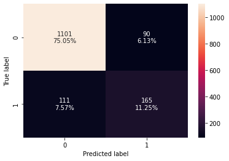

```python
confusion_matrix_sklearn(abc_tuned, X_test,y_test)
```

```python
abc_tuned_model_train_perf=model_performance_classification_sklearn(abc_tuned, X_train,y_train)
print("Training performance \n",abc_tuned_model_train_perf)
```

```
Training performance
    Accuracy    Recall  Precision        F1
0   0.97223  0.908385   0.942029  0.924901
```

```python
abc_tuned_model_test_perf=model_performance_classification_sklearn(abc_tuned, X_test, y_test)
print("Testing performance \n",abc_tuned_model_test_perf)
```

```
Testing performance
    Accuracy    Recall  Precision        F1
0  0.862986  0.597826   0.647059  0.621469
```

#### Tuning the Adaboost model significantly increased the F1 score from .45 to .62, however this is still low performance and has overfitting of the train data set.

#### Gradient Booster with Tuning

```python
# Choose the type of classifier.
gbc_tuned = GradientBoostingClassifier(init=AdaBoostClassifier(random_state=1),random_state=1)

# Grid of parameters to choose from
## add from article
parameters = {
    "n_estimators": [100,150,200,250],
    "subsample":[0.8,0.9,1],
    "max_features":[0.7,0.8,0.9,1]
}


# Run the grid search
grid_obj = GridSearchCV(gbc_tuned, parameters, scoring=acc_scorer,cv=5)
grid_obj = grid_obj.fit(X_train, y_train)

# Set the clf to the best combination of parameters
gbc_tuned = grid_obj.best_estimator_

# Fit the best algorithm to the data.
gbc_tuned.fit(X_train, y_train)
```

```
GradientBoostingClassifier(init=AdaBoostClassifier(random_state=1),
                           max_features=0.9, n_estimators=250, random_state=1,
                           subsample=0.9)
```

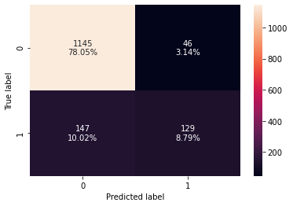

```python
confusion_matrix_sklearn(gbc_tuned, X_test,y_test)
```

```python
gbc_tuned_model_train_perf=model_performance_classification_sklearn(gbc_tuned, X_train,y_train)
print("Training performance \n",gbc_tuned_model_train_perf)
```

```
Training performance
    Accuracy    Recall  Precision        F1
0   0.91026  0.579193    0.91198  0.708452
```

```python
gbc_tuned_model_test_perf=model_performance_classification_sklearn(gbc_tuned, X_test, y_test)
print("Testing performance \n",gbc_tuned_model_test_perf)
```

```
Testing performance
    Accuracy    Recall  Precision        F1
0  0.868439  0.467391   0.737143  0.572062
```

## Section 8: Actionable Insights and Recommendation

- Model performance on various insights comparison
- Key Takeaways
- Advice for establishing a viable business model to expand the customer base

#### Key Takeaways

The best model that was produced so far was the random forest estimator model which has a success metric (F1 score) of 76%. I am concerned about potential overfitting in this model. Because of this, I do nto believe my work is done, however, I have run out of time to work on the project.

Given more time, my next steps would be to

- tune the XGBoost model to see if I could return a better score
- Run models on a subset of features, the ones determined to be the most important, in order to eliminate noise and improve the model.
- The most important features for predicting ProdTaken are Monthly Income, Age, Duration of Pitch followed by Number of Trips, Passport, Number of Follow-ups
- Number of Trips
  - Most customers took 1,2 or 3 trips: 30% of data points - 2 trips, 24% - 3 trips, 13% - 1 trip;
  - Number of Trips seems to affect ProdTaken for Number of Trips greater than 3; the more trips taken the higher the percentage of prodTaken with 7 and 8 days approximaltey equal at 18.4% and 27.6%, respectively
- Monthly Income
  - Median Monthly Income for those taking each type of product: Basic: 20582, Deluxe: 23186, King: 34859; Standard: 25711, and Super Deluxe: 29802
- Age
  - Median ages of customers purchasing each product: Basic: 30, Deluxe: 36, King: 52.5, Standard: 38 and Super Deluxe: 42
- Duration of Pitch
  - ProductPitched: Median Duration of Pitch: Basic:13, Deluxe:14, King: 11; Standard: 14; Super Deluxe: 13
- Passport
  - Of those customers who purchased a product 54% had a passport
- Number of Follow-ups
  - Follow-up rate does not change significantly when disaggregated by ProductPitched
  - Percent ProdTaken increase as number of Followups increases and Number of followups >=2
- Surprisingly, Gender and Marital status were not as predictive #### Customer Profiles per Product type
- Basic
  - Product Pitched and ProdTaken Median Age: 30
  - Pitched primarily to City Tier 1 and City Tier 2 customers
  - Males were pitched Basic more than any other product type
  - Median income: 20582
  - Median Duration of Pitch:13
- Deluxe
  - Product Pitched and ProdTaken Median Age: 36
  - Customers in City Tier 3 were pitched this products most often
  - Females were pitched Deluxe more often that any other product type however, females do not appear to purchase the deluxe product at a higher rate than males
  - Married customers are mmore likley than no married couples to purchse Deluxe
  - Median Income: 23186
  - Median Duration of Pitch: 14
- King
  - Product Pitched and ProdTaken Median Age: 52
  - Married couples are more liley to purchase King Product that unmarried
  - Owning a car appears to influence the purchase of the King Product; Of those customers who were pitched a King product, 72% owned a car; Customers who buy the King Products have a higher rate of car ownership (90%) than those who take the other products (however these groups have a small number of customer each so consider size in evaluation)
  - Median Income: 34859
  - Median Duration of Pitch:11
- Standard
  - Product Pitched and ProdTaken Median Age: 38
  - Median number of trips is slightly lower for customers who purchse Standard
  - Product is pitched to all occupation groups
  - Median Income: 25711
  - Median Duration of Pitch: 14
- Super Deluxe
  - Product Pitched and ProdTaken Median Age: 42
  - Out of those who take the Super Deluxe product, 80% are company invited and 20% are self-enquiry
  - Purchase of product is influneced by a Preferredproperty star of 3 or greater
  - Number of Trips is slightly lower for those customers who purchase Super Deluxe
  - Median Income: 29802
  - Median Duration of Pitch: 13

#### Advice to business

I would use the model as a means of predicting but I would use it with caution. I would recommend that the business also consider the EDA analysis and utilize this to target customer groups in their sales process. Fortargeting customer groups, I would rely heavily on Monthly Income data to fetermine which products to pitch to potential clients. The median monthly income data combined with Age group analysis and other slightly less dominant features can act as a guide toward product being pitched to customer groups. Additionally, I would train my sales people on ideal pitch durations and number of follow-ups as these also appear to be a driver of success.